# Team_Lab5

Evan Mills, Max Farver

April 17, 2019

```r
library(ggplot2)
library(dplyr)
acc <- read.csv("https://raw.githubusercontent.com/xdaiISU/ds202materials/master/hwlabs/fars2017/accident.csv", stringsAsFactors = FALSE)
```

```r
pers <- read.csv("https://raw.githubusercontent.com/xdaiISU/ds202materials/master/hwlabs/fars2017/person.csv", stringsAsFactors = FALSE)
```

Part One: Acciednt Data

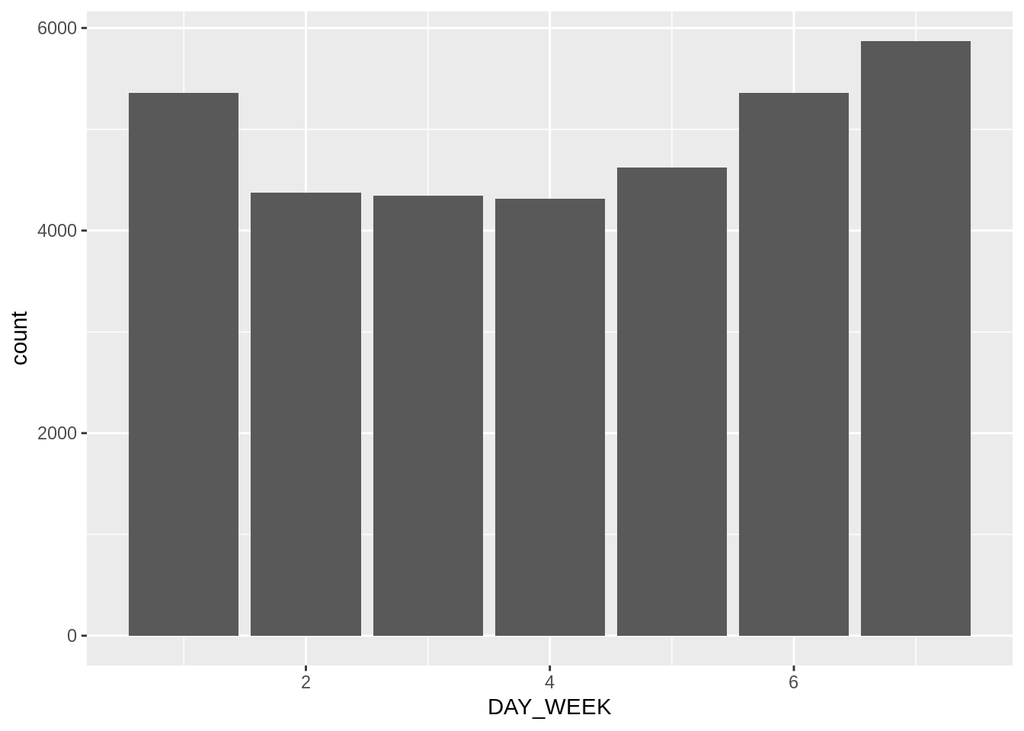

```r
ggplot(data = acc, aes(x = DAY_WEEK)) + geom_bar()
```

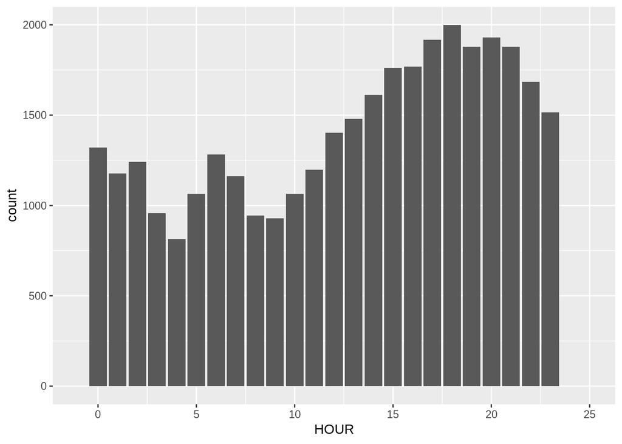

```r
ggplot(data = acc, aes(x = HOUR), colour = HOUR) + geom_bar() + xlim(c(-1,25))
```

As you can see from the chat above the greatest number of accidents happens at hour 18 which equates to 6:00 pm. However the time period that accounts for most of the accidents is hour 14 to hour 22, which in non-24 hour time is 2:00 pm to 10:00 pm. This corrlates with the time period know as rush hour.

```r
dui <- acc %>% select(DRUNK_DR) %>% filter(DRUNK_DR >= 1)

dim(dui)
```

```
## [1] 8769    1
```

```r
unique(acc$YEAR)
```

```
## [1] 2017
```

There were 8769 accidents that involved at least one drunk driver in 2017.

Part two: Connecting data

```r
drivers <- filter(pers, PER_TYP == 1)
```

Joining the tables

```r
joined <- full_join(acc, pers, by = c("STATE", "ST_CASE", "VE_FORMS", "COUNTY", "DAY", "MONTH", "HOUR", "MINUTE", "RUR_URB", "FUNC_SYS","HARM_EV", "MAN_COLL"))
names(joined)
```

```
##   [1] "STATE"      "ST_CASE"    "VE_TOTAL"   "VE_FORMS"   "PVH_INVL"
##   [6] "PEDS"       "PERNOTMVIT" "PERMVIT"    "PERSONS"    "COUNTY"
##  [11] "CITY"       "DAY"        "MONTH"      "YEAR"       "DAY_WEEK"
##  [16] "HOUR"       "MINUTE"     "NHS"        "RUR_URB"    "FUNC_SYS"
##  [21] "RD_OWNER"   "ROUTE"      "TWAY_ID"    "TWAY_ID2"   "MILEPT"
##  [26] "LATITUDE"   "LONGITUD"   "SP_JUR"     "HARM_EV"    "MAN_COLL"
##  [31] "RELJCT1"    "RELJCT2"    "TYP_INT"    "WRK_ZONE"   "REL_ROAD"
##  [36] "LGT_COND"   "WEATHER1"   "WEATHER2"   "WEATHER"    "SCH_BUS.x"
##  [41] "RAIL"       "NOT_HOUR"   "NOT_MIN"    "ARR_HOUR"   "ARR_MIN"
##  [46] "HOSP_HR"    "HOSP_MN"    "CF1"        "CF2"        "CF3"
##  [51] "FATALS"     "DRUNK_DR"   "VEH_NO"     "PER_NO"     "STR_VEH"
##  [56] "SCH_BUS.y"  "MAKE"       "MAK_MOD"    "BODY_TYP"   "MOD_YEAR"
##  [61] "TOW_VEH"    "SPEC_USE"   "EMER_USE"   "ROLLOVER"   "IMPACT1"
##  [66] "FIRE_EXP"   "AGE"        "SEX"        "PER_TYP"    "INJ_SEV"
##  [71] "SEAT_POS"   "REST_USE"   "REST_MIS"   "AIR_BAG"    "EJECTION"
##  [76] "EJ_PATH"    "EXTRICAT"   "DRINKING"   "ALC_DET"    "ALC_STATUS"
##  [81] "ATST_TYP"   "ALC_RES"    "DRUGS"      "DRUG_DET"   "DSTATUS"
##  [86] "DRUGTST1"   "DRUGTST2"   "DRUGTST3"   "DRUGRES1"   "DRUGRES2"
##  [91] "DRUGRES3"   "HOSPITAL"   "DOA"        "DEATH_DA"   "DEATH_MO"
##  [96] "DEATH_YR"   "DEATH_HR"   "DEATH_MN"   "DEATH_TM"   "LAG_HRS"
## [101] "LAG_MINS"   "P_SF1"      "P_SF2"      "P_SF3"      "WORK_INJ"
## [106] "HISPANIC"   "RACE"       "LOCATION"
```

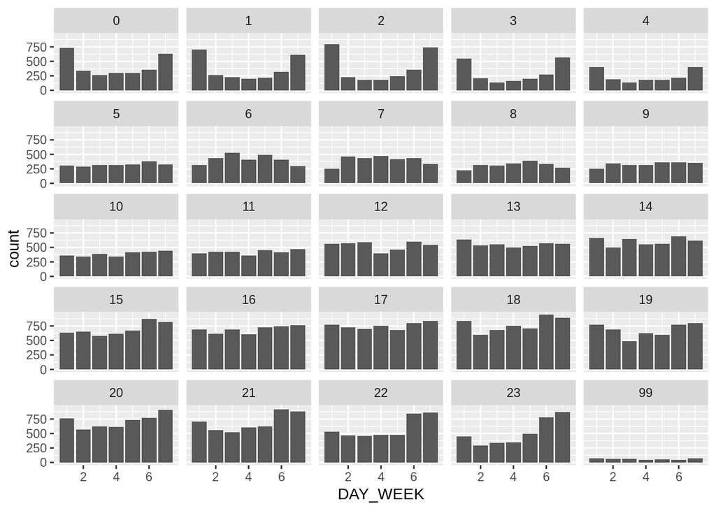

```r
ggplot(data = joined, aes(DAY_WEEK)) + geom_bar() + facet_wrap(joined$HOUR)
```

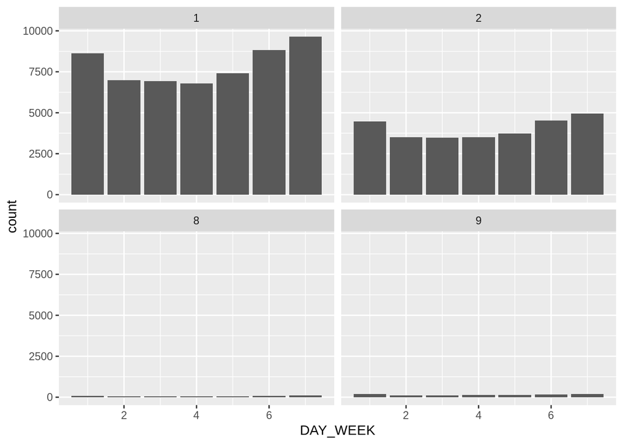

```r
ggplot(data = joined, aes(DAY_WEEK)) + geom_bar() + facet_wrap(joined$SEX)
```

Part 3)

```r
library(readxl)
glc <- readxl::read_xlsx("/home/max/Documents/Iowa State/DS_202/ds202_lab5/FRPP_GLCU.xlsx", skip = 1)
glc$`State Code` <- as.numeric(glc$`State Code`)

glc$`County Code` <- as.numeric(glc$`County Code`)

full <- left_join(joined, glc, by = c('STATE' = 'State Code', 'COUNTY' = 'County Code'))
```

```r
library(maps)
counties <- map_data("county")
```

```r
##########  you should try to fix this  ####################


full <- full %>% filter(LONGITUD < 0, LONGITUD > -130)

full <- full %>% arrange(desc(COUNTY))
```

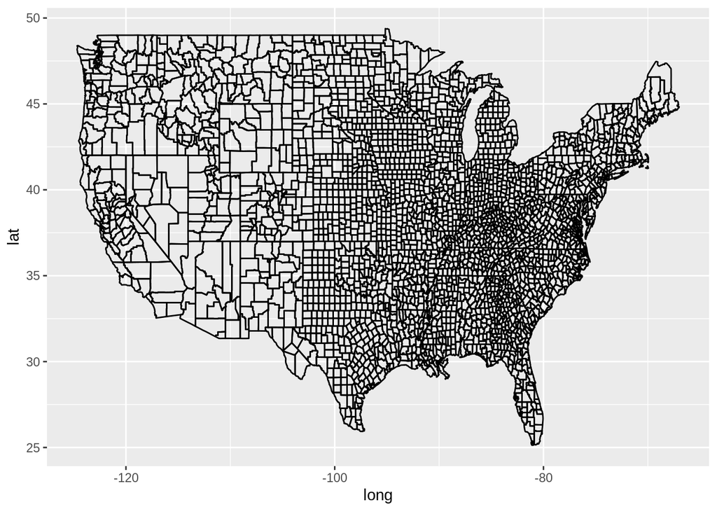

```r
ggplot() +
  geom_path(data=counties, aes(x =long, y=lat, group = group))
```

```r
  #geom_path(data=full, aes(x=LONGITUD, y=LATITUDE, group=STATE))
```

```r
winter <- acc %>% filter(MONTH %in% c(1,2,12))

summer <- acc %>% filter(MONTH %in% c(6,7,8))

nrow(winter)
```

```
## [1] 7733
```

```r
nrow(summer)
```

```
## [1] 9205
```

As you can see from the numbers above, there surprisingly tends to be more accidents in Summer than in Winter. This could be due to more people enjoying the weather and drinking more, or driving faster due to feeling more confident on the road.